[figure not shown]

# Introduction

This is a dataset for Ford GoBike Service for Feb - 2019 , It consists of 170 K information about the trip and the users such as thier gender and age.

Ford GoBike is the Bay Area’s bike share system. Bay Area Bike Share was introduced in 2013. It services San Francisco, the East Bay and San Jose. Similar to other bike share systems, Ford GoBike consists of a fleet of bikes that can be unlocked in one station and returned in any other network station. Thus, this is ideal for one-way trips. These bikes are available for use thorughout the year and riders have access to all bikes in the network.

**Dataset Dictionary:**

1- duration_sec: Trip Duration

2- start_time :start time for each trip

3- end_time : end time for each trip

4- start_station_id

5- start_station_name

6- start_station_latitude

7- start_station_longitude

8- end_station_id

9- end_station_name

10- end_station_latitude

11- end_station_longitude

12- bike_id

13- user_type: User Type (Subscriber or Customer – “Subscriber” = Member or “Customer” = Casual)

14 - member_birth_year: Member Year of Birth

15member_gender

16- bike_share_for_all_trip: Boolean to track members who are enrolled in the "Bike Share for All" program for low-income residents

# Gender of Ford GoBike Users

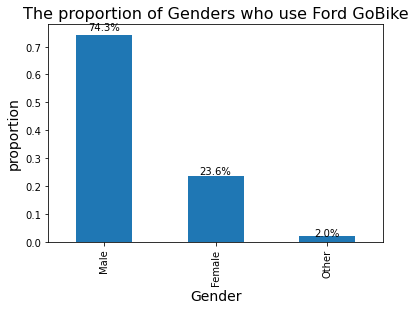

# Weekdays of Ford GoBike rides

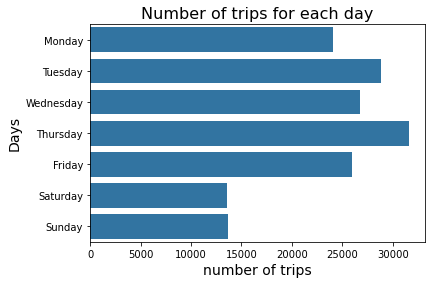

**1- In the weekdays people use the Ford GoBike service more than the weekends.**

**2- Thursday has the highest trips.**

**3- Saturday and Sunday which are the weekend days has the less use of the service.**

# Subscribers VS Customers

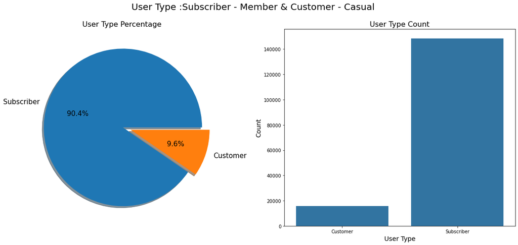

**1- As shown in the figure users who are subscribe are more than customer users.**

**2 - The subscriber riders achive 90.4% rides , and 9.6% from the trips are customers.**

# Age range of Ford GoBike Riders

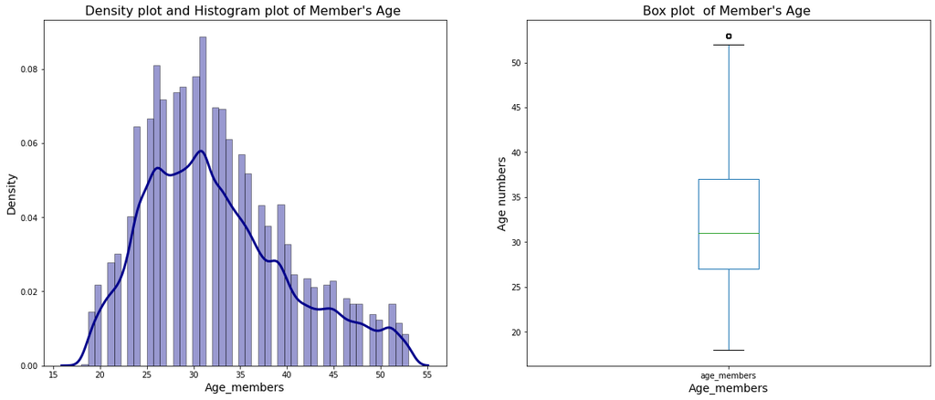

**1- The Average age of the riders is 32.4.**

**2- The highest age of the users who is using the service is 32 years old.**

**3- The age between 25 to 35 has the heaviest number of rides.**

# Top 20 startoff stations

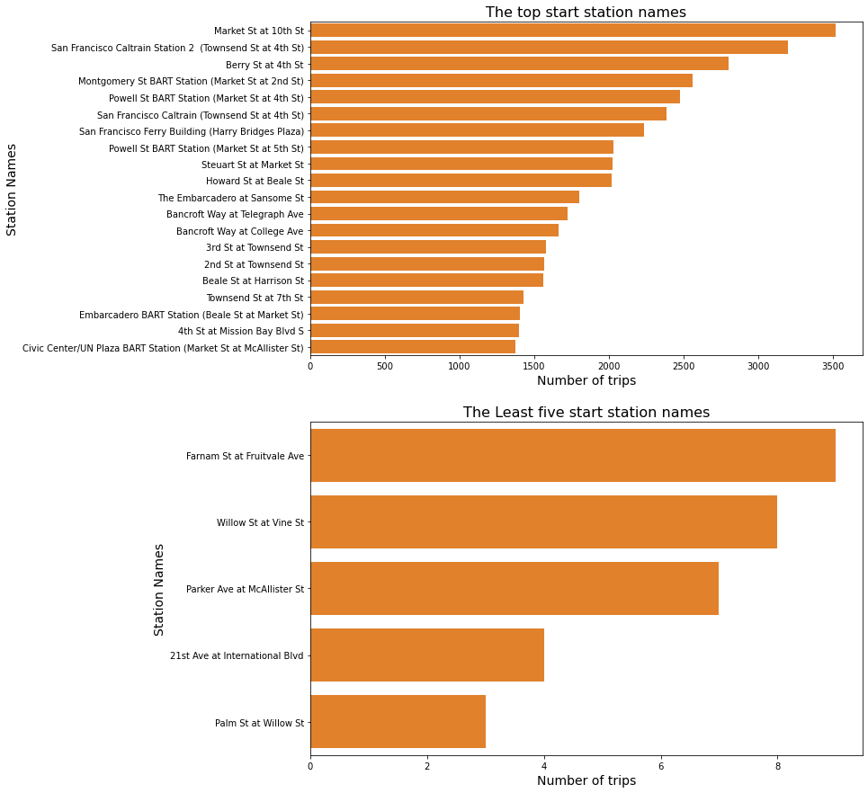

**1- Market St at 10th St & San Francisco Caltrain Station 2 (Townsend St at 4th St) have the highest number of rides.**

# Bike Share for All Program

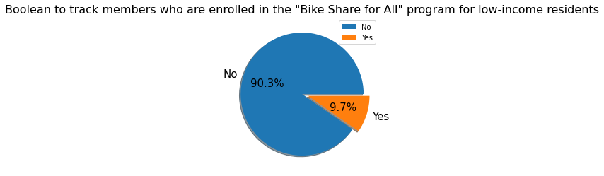

**The number of memebers who did not enrolled in the program are more than who did , which 90.3% didn't enrolled and just 9.7% enrolled.**

# Distance of trips in Km

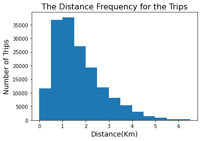

**1- The most distance over the trips is between 0.5 Km and 1.5 Km.**

**2- 6 Km has the least number of trips.**

# Duration of Trips

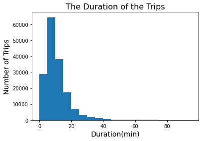

**1- The number of trips refernce to the duration in min is skewed to the right.**

**2- The average duration of the total trips in min is 11.7 min .**

**3- The minimum duration of the trips is 1.0 min and the max is 1409 min.**

# - Bivariate Exploration of Data

# The distribution of member who enrolled in "Bike Share for All" and the user type across the gender

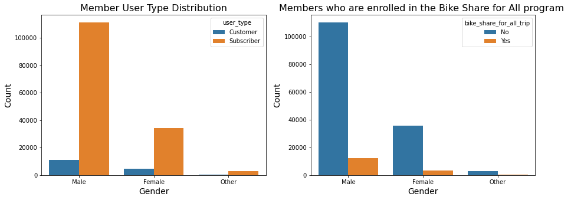

**1- The number of males who are subscribers are more than the females subscribers.**

**2- Also the numbe of males customers are more than the females customers.**

**3- The number of males who enrolled and did'nt enrolled are more than the females in both.**

# The distribution of genders reference to the days and the duration of the trips

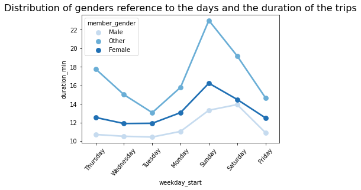

**1- The duration of the trips for males is on the peak on Sunday & Saturday.**

**2 - The duration of the trips for females is on the peak on Sunday.**

# The hours of the day according to the weekdays have high trafic on trips

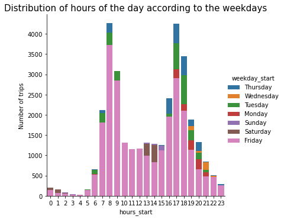

**As mentioned earlier Thursday contain more trips but from this graph we will notice that the trafic is at 17 and 18 pm.**

# The distribution of hours of the trip according to the user type

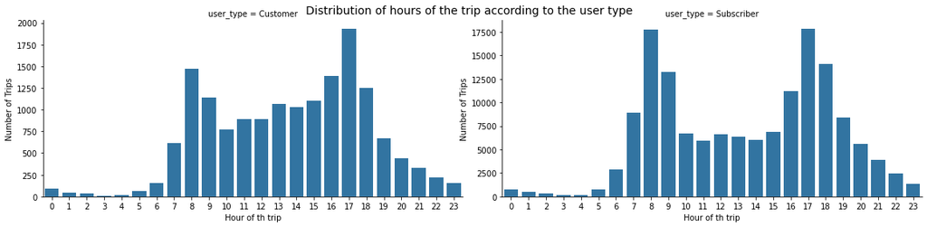

**1- For the Customers the highest hour in the day is 17 pm , it has the largest number of trips.**

# The allocation of the users according to the age and the duration of the trips

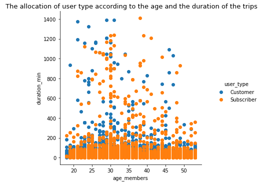

**The trafic of the trips according to te user type spreading on all over the age is between 0 and 150 min.**

# The allocation of the users according to the distance in Km along the trips

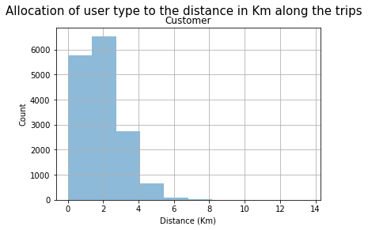

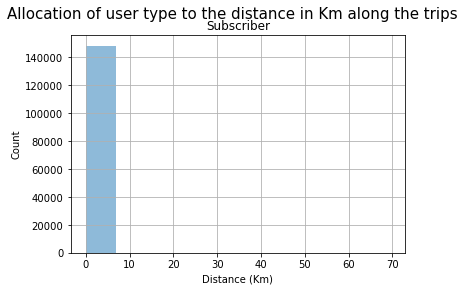

**1-ِAlong the distance customers are skeweed to the right.**

**2- subscribers cut distance between 0 and around 7 Km.**

# Conclusion:

I had invistigate in a dataset for Ford GoBike service for feb 2019 , from this dataset we can realize that:

**1- Age:**

- Above 53 years old are outlires and I think it is normal.
- Average age of the riders is 32.4.
- The hieghest age of the users who is using the service is 32 years old.
- Age between 25 to 35 has the heaviest number of rides.

**2- Gender:**

- In the weekdays people use the Ford GoBike service more than the weekends.
- Thursday has the heighest trips.
- Saturday and Sunday which are the weekend days has the less use of the service.

**4- Distance in Km:**

- The most distance over the trips is between 0.5 Km and 1.5 Km.
- 6 Km has the least number of trips.

**5- Hours of the day:**

- 8 am and 17 pm have the heaviest startoff rides , which is in the range of official working hours.

**7- User type:**

- Users who are subscribe are more than customer users.
- Subscriber riders achive 90.4% rides , and 9.6% from the trips are customers
- Number of males who are subscribers are more than the females subscribers.
- Also the numbe of males customers are more than the females customers.

**8-Bike Share for All program:**

- The number of memebers who did not enrolled in the program are more than who did , which 90.3% didn't enrolled and just 9.7% enrolled.
- The number of males who enrolled and did'nt enrolled are more than the females in both.

**9- Duration in min:**

- The average duration of the total trips in min is 11.7 min .
- The minimum duration of the trips is 1.0 min and the max is 1409 min.

# limitations:

1-More data to know why number of customers are low.

3-There are 873 ride with 1 min duration. We need to know why this short trip.

4-More data to know why the duration of the trips are not long.